# BoundaryStats analysis of Barratt et al. 2018 amphibian data

Amy Luo

2022-09-15

# BoundaryStats vignette with East African amphibian data

This vignette is a walkthrough of the workflow for calculating boundary statistics and boundary overlap statistics for two ecological variables. This vignette uses East African ecoregion data and genomic analyses from Barratt et al. 2018. The following code tests for (1) whether there are significant geographic boundaries between genetic groups of the frog species *Afrixalus delicatus* and (2) whether those boundaries overlap significantly with ecoregion boundaries.

## Load packages used in this vignette

```r
library(BoundaryStats)
library(magrittr)
library(raster)
```

## Input data

### Ecoregion data

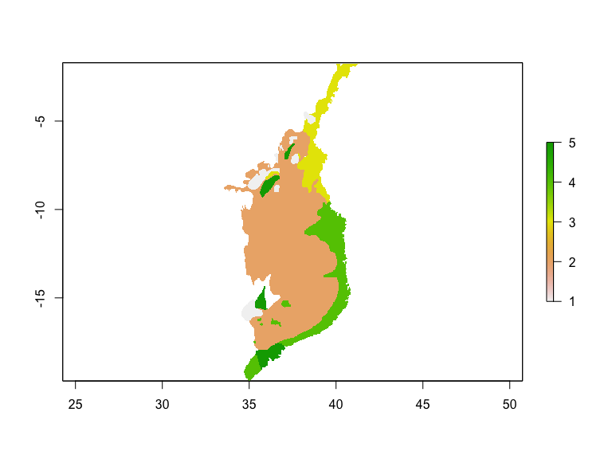

```r
data(ecoregions)
plot(ecoregions)
```

### Genetic data

These data are based on the ADMIXTURE results from Barratt et al. 2018. The point data (assignment probabilities for each individual) have been interpolated using universal kriging to produce a raster surface.

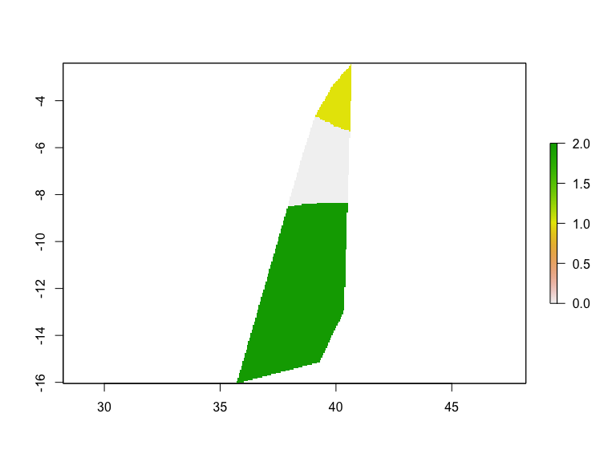

```r
data(A.delicatus)
plot(A.delicatus)
```

## Define trait boundaries and ecoregion boundaries

In order to test for significant overlap between the traits, the RasterLayer objects need to be aligned in extent and resolution. The ecoregion surface is first resampled to the resolution of the genetic data, then cropped to the area of the genetic surface. Then the boundaries are defined with the function categorical_boundary(). Before defining boundaries between genetic groups, the genetic surface is also cropped to the area of the new ecoregion surface, since it originally includes space off the East African coastline.

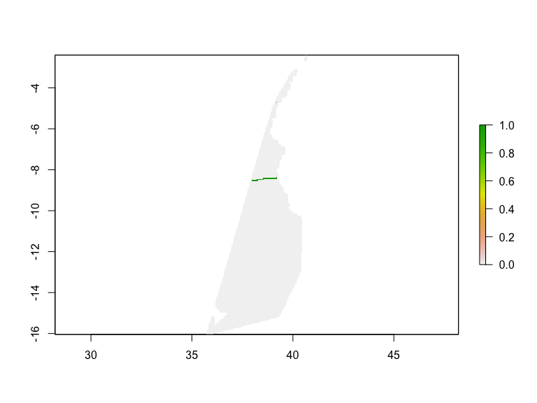

```r
A.delicatus_ecoregion <- resample(ecoregions, A.delicatus) %>%
  crop(., A.delicatus) %>%
  mask(., A.delicatus) %>%
  categorical_boundary(., projection = 4210)
A.delicatus <- crop(A.delicatus, A.delicatus_ecoregion) %>%
  mask(., A.delicatus_ecoregion)
A.delicatus <- categorical_boundary(A.delicatus, projection = 4210)
plot(A.delicatus)
```

## Plot boundary overlap

The overlap in boundaries between two variables can be plotted using the plot_boundary() function.

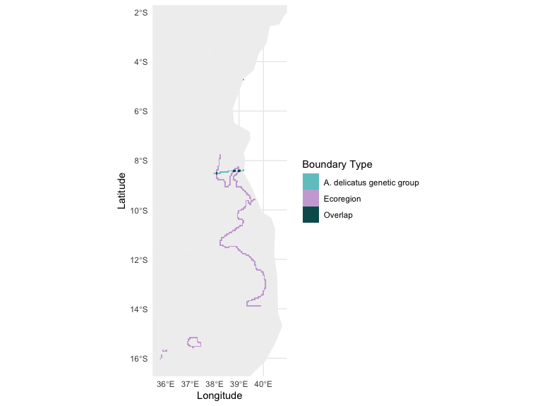

```r
plot_boundary(A.delicatus, A.delicatus_ecoregion, trait_names = c('A. delicatus genetic group', 'Ecoregion'))
```

## Calculate boundary statistics

### Create null distributions

The function boundary_null_distrib() simulates neutral landscapes based on the input data and the selected neutral model. The default number of iterations is 10, but a value between 100 and 1000 is recommended. This step may take a while, depending on the neutral model and number of iterations!

Multiple neutral models are available: complete stochasticity (default), random Gaussian fields, simultaneous spatial autoregressive models, and modified random cluster. Random cluster models are suited to categorical variables (cat = T), so we use it here.

```r
A.deli_bound.null <- boundary_null_distrib(A.delicatus, cat = T, n_iterations = 100, projection = 4210, model = 'random_cluster', progress = F)
```

```
#> DONE
```

### Run statistical tests

n_subgraph is the number of subgraphs (i.e., contiguous groups of cells representing boundaries), and max_subgraph is the length of the longest subgraph.

```r
n_subgraph(A.delicatus, A.deli_bound.null)
```

```
#> n subgraphs     p-value
#>           2           0
```

```r
max_subgraph(A.delicatus, A.deli_bound.null, projection = 4210)
```

```
#> length of longest boundary                    p-value
#>                   139272.5                        0.0
```

## Calculate boundary overlap statistics

### Create null distributions

overlap_null_distrib() runs much like boundary_null_distrib(), but takes raster surfaces for two traits (x and y), along with arguments for each trait.

```r
A.deli_overlap.null <- overlap_null_distrib(A.delicatus, A.delicatus_ecoregion, x_cat = T, y_cat = T, n_iterations = 100, projection = 4210, x_model = 'random_cluster', y_model = 'random_cluster', progress = F)
```

```
#> DONE
```

### Run statistical tests

Odirect is the number of directly overlapping boundary elements between the two variables. Ox is the average minimum distance for a boundary element in variable x to a boundary element in variable y. It assumes that the boundaries in xdepend on the boundaries in y. Here, genetic group boundaries rely on ecoregion boundaries. Oxy is the average minimum distance between boundary elements in x and y (x and y affect each other reciprocally).

```r
Odirect(A.delicatus, A.delicatus_ecoregion, A.deli_overlap.null)
```

```
#> n overlapping boundary elements                         p-value
#>                       5.0000000                       0.2253529
```

```r
Ox(A.delicatus, A.delicatus_ecoregion, A.deli_overlap.null)
```

```
#> average minimum distance (x depends on y)
#>                                 4.2603950
#>                                   p-value
#>                                 0.1905859
```

```r
Oxy(A.delicatus, A.delicatus_ecoregion, A.deli_overlap.null)
```

```
#> average minimum distance                  p-value
#>              53.65928661               0.06168645
```

## Citations

Barratt, C.D., Bwong, B.A., Jehle, R., Liedtke, C.H., Nagel, P., Onstein, R.E., Portik, D.M., Streicher, J.W. & Loader, S.P. (2018) Vanishing refuge? Testing the forest refuge hypothesis in coastal East Africa using genome‐wide sequence data for seven amphibians. Molecular Ecology, 27, 4289-4308.